# Multi-class Classification Exercise

Norihito Nakata

10/29/2018

## Getting and Cleaning data

The goal of your project is to predict the manner in which they did the exercise. I use devices such as Jawbone Up, Nike FuelBand, and Fitbit it is now possible to collect a large amount of data about personal activity relatively inexpensively.

```r
rm(list=ls())
# Download csv file from web page
if (!file.exists("./training.csv")) {
    download.file("https://d396qusza40orc.cloudfront.net/predmachlearn/pml-training.csv",
                  destfile = "./training.csv")
}
if (!file.exists("./testing.csv")) {
    download.file("https://d396qusza40orc.cloudfront.net/predmachlearn/pml-testing.csv",
                  destfile = "./testing.csv")
}
training <- read.csv("training.csv")
testing <- read.csv("testing.csv")
dim(training); dim(testing)
```

```
## [1] 19622   160
```

```
## [1]  20 160
```

The dataset has 160 columns, but some columns NAs. First, I exclude the columns which has more NAs than 95% in that column, and the number of columns is reduced from 160 to 93. Next, I exclude the columns which has near zero variance because this kind of feature has the distorted frequency in this column. By excluding near zero variance, the number of columns is reduced to 59. And then, I removed column 1 to 5, which are not features.

```r
str(training)
```

```
## 'data.frame':    19622 obs. of  160 variables:
##  $ X                       : int  1 2 3 4 5 6 7 8 9 10 ...
##  $ user_name               : Factor w/ 6 levels "adelmo","carlitos",..: 2 2 2 2 2 2 2 2 2 2 ...
##  $ raw_timestamp_part_1    : int  1323084231 1323084231 1323084231 1323084232 1323084232 1323084232 1323084232 1323084232 1323084232 1323084232 ...
##  $ raw_timestamp_part_2    : int  788290 808298 820366 120339 196328 304277 368296 440390 484323 484434 ...
##  $ cvtd_timestamp          : Factor w/ 20 levels "02/12/2011 13:32",..: 9 9 9 9 9 9 9 9 9 9 ...
##  $ new_window              : Factor w/ 2 levels "no","yes": 1 1 1 1 1 1 1 1 1 1 ...
##  $ num_window              : int  11 11 11 12 12 12 12 12 12 12 ...
##  $ roll_belt               : num  1.41 1.41 1.42 1.48 1.48 1.45 1.42 1.42 1.43 1.45 ...
##  $ pitch_belt              : num  8.07 8.07 8.07 8.05 8.07 8.06 8.09 8.13 8.16 8.17 ...
##  $ yaw_belt                : num  -94.4 -94.4 -94.4 -94.4 -94.4 -94.4 -94.4 -94.4 -94.4 -94.4 ...
##  $ total_accel_belt        : int  3 3 3 3 3 3 3 3 3 3 ...
##  $ kurtosis_roll_belt      : Factor w/ 397 levels "","-0.016850",..: 1 1 1 1 1 1 1 1 1 1 ...
##  $ kurtosis_picth_belt     : Factor w/ 317 levels "","-0.021887",..: 1 1 1 1 1 1 1 1 1 1 ...
##  $ kurtosis_yaw_belt       : Factor w/ 2 levels "","#DIV/0!": 1 1 1 1 1 1 1 1 1 1 ...
```

[output cut: 86 more lines]

```r
# Exclude the columns
trainingSet <- training[, which(sapply(training, function(x){mean(is.na(x)) < 0.95}))]
testingSet <- testing[, which(sapply(training, function(x){mean(is.na(x)) < 0.95}))]
dim(trainingSet); dim(testingSet)
```

```
## [1] 19622    93
```

```
## [1] 20 93
```

```r
# Exclude near Zero Variance columns
library(caret)
nzv <- nearZeroVar(trainingSet)
trainingSet <- trainingSet[, -nzv]
testingSet <- testingSet[, -nzv]
dim(trainingSet); dim(testingSet)
```

```
## [1] 19622    59
```

```
## [1] 20 59
```

```r
# Exclude first 5 columns which is default.
trainingSet <- trainingSet[, -(1:5)]
testingSet <- testingSet[, -(1:5)]
dim(trainingSet); dim(testingSet)
```

```
## [1] 19622    54
```

```
## [1] 20 54
```

I separate training data to `trainSet` and `testSet`. `trainSet` is to build models, and `testSet` is to select the best model among the learned models.

```r
set.seed(1234)
trainIndex <- createDataPartition(trainingSet$classe, p=0.75, list = FALSE)
trainSet <- trainingSet[trainIndex,]
testSet <- trainingSet[-trainIndex,]
```

## Exploratory Data Analysis

The extracted columns has 53 features and `classe` is the outcome. I plot correlation of 53 features to see the relation between features. Highly correlated features are dark colors.

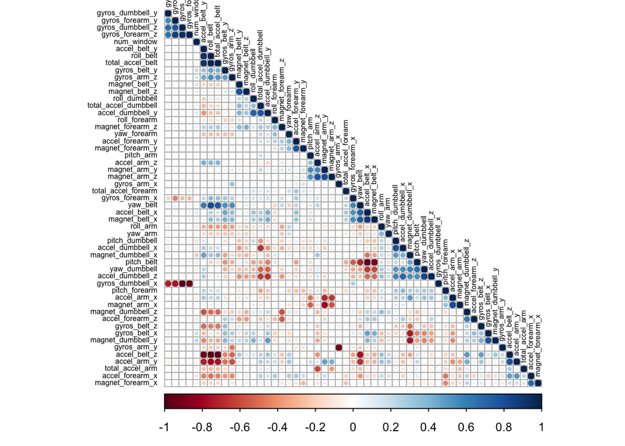

```r
library(corrplot)
corrMatrix <- cor(trainSet[, -54])
corrplot(corrMatrix, method="circle", type="lower", order="hclust", tl.cex = 0.5, tl.col="black")
```

## Create Prediction Model

This problem is multi-class classification so I use tree-base methods, *decision tree*, *random forest* and *gradient boost* to choose a better model.

### Decision tree

```r
library(rpart)
library(rattle)
```

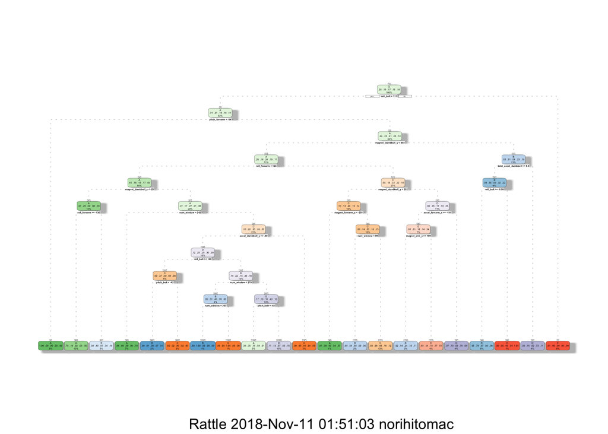

```r
set.seed(1234)
mdlFit_DT <- rpart(classe ~ ., data=trainSet, method="class")
fancyRpartPlot(mdlFit_DT)
```

```r
printcp(mdlFit_DT)
```

```
##
## Classification tree:
## rpart(formula = classe ~ ., data = trainSet, method = "class")
##
## Variables actually used in tree construction:
##  [1] accel_dumbbell_y     accel_forearm_x      magnet_arm_y
##  [4] magnet_dumbbell_y    magnet_dumbbell_z    magnet_forearm_z
##  [7] num_window           pitch_belt           pitch_forearm
## [10] roll_belt            roll_forearm         total_accel_dumbbell
##
## Root node error: 10533/14718 = 0.71565
##
## n= 14718
##
##          CP nsplit rel error  xerror      xstd
## 1  0.115352      0   1.00000 1.00000 0.0051957
## 2  0.059875      1   0.88465 0.88465 0.0055511
## 3  0.038356      4   0.70502 0.79787 0.0057006
## 4  0.034463      6   0.62831 0.60761 0.0057098
## 5  0.029906      7   0.59385 0.58236 0.0056786
## 6  0.024257      8   0.56394 0.55957 0.0056437
## 7  0.022311     10   0.51543 0.49483 0.0055084
## 8  0.020507     11   0.49312 0.48068 0.0054715
## 9  0.019558     12   0.47261 0.47109 0.0054449
## 10 0.018988     13   0.45305 0.44508 0.0053662
## 11 0.014336     14   0.43406 0.42486 0.0052983
## 12 0.013197     15   0.41973 0.38375 0.0051407
## 13 0.011630     16   0.40653 0.35906 0.0050328
## 14 0.011203     18   0.38327 0.34634 0.0049731
## 15 0.011013     19   0.37207 0.34083 0.0049463
## 16 0.010000     20   0.36106 0.32242 0.0048525
```

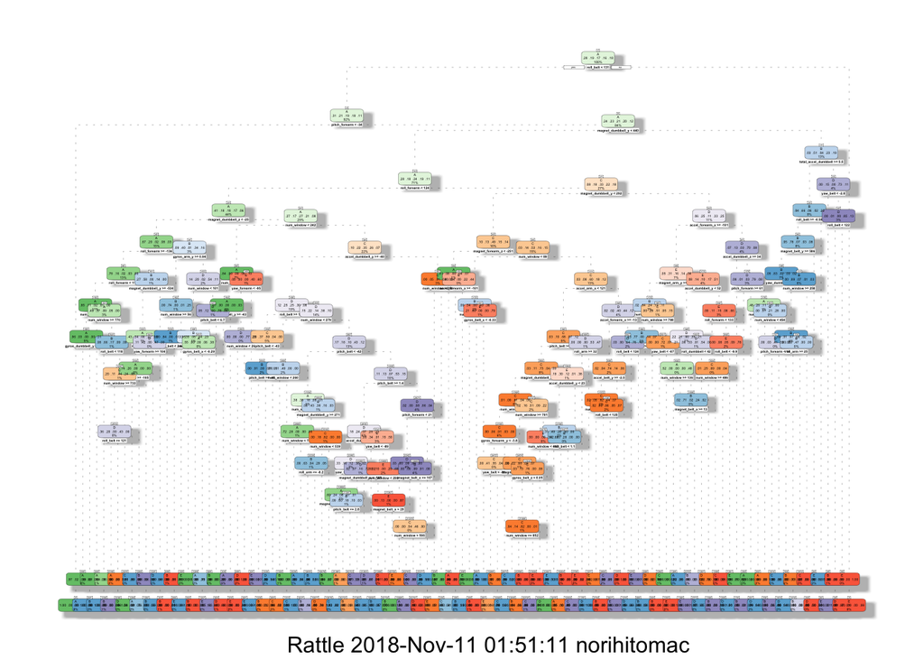

```r
tc <- trainControl("cv",4)
rpart.grid <- expand.grid(.cp=0.001)
mdlFit_DT <- train(classe ~ ., data=trainSet, method="rpart", trControl=tc, tuneGrid=rpart.grid)
fancyRpartPlot(mdlFit_DT$finalModel)
```

```r
mdlFit_DT
```

```
## CART
##
## 14718 samples
##    53 predictor
##     5 classes: 'A', 'B', 'C', 'D', 'E'
##
## No pre-processing
## Resampling: Cross-Validated (4 fold)
## Summary of sample sizes: 11040, 11038, 11039, 11037
## Resampling results:
##
##   Accuracy   Kappa
##   0.9501951  0.9370003
##
## Tuning parameter 'cp' was held constant at a value of 0.001
```

```r
predict_DT <- predict(mdlFit_DT, newdata = testSet)
confusionMatrix(predict_DT, testSet$classe)
```

```
## Confusion Matrix and Statistics
##
##           Reference
## Prediction    A    B    C    D    E
##          A 1364   36    3    5    6
##          B   11  858   22   17   19
##          C    2   28  794   29    9
##          D   12   11   26  741   23
##          E    6   16   10   12  844
##
## Overall Statistics
##
##                Accuracy : 0.9382
##                  95% CI : (0.9311, 0.9448)
##     No Information Rate : 0.2845
##     P-Value [Acc > NIR] : < 2e-16
##
##                   Kappa : 0.9218
##  Mcnemar's Test P-Value : 0.01357
##
## Statistics by Class:
##
##                      Class: A Class: B Class: C Class: D Class: E
## Sensitivity            0.9778   0.9041   0.9287   0.9216   0.9367
## Specificity            0.9858   0.9826   0.9832   0.9824   0.9890
## Pos Pred Value         0.9646   0.9256   0.9211   0.9114   0.9505
## Neg Pred Value         0.9911   0.9771   0.9849   0.9846   0.9858
## Prevalence             0.2845   0.1935   0.1743   0.1639   0.1837
## Detection Rate         0.2781   0.1750   0.1619   0.1511   0.1721
## Detection Prevalence   0.2883   0.1890   0.1758   0.1658   0.1811
## Balanced Accuracy      0.9818   0.9433   0.9559   0.9520   0.9629
```

### Random forest

```r
set.seed(1234)
mdlFit_RF <- train(classe ~ ., data = trainSet, method="rf", trControl=tc)
mdlFit_RF
```

```
## Random Forest
##
## 14718 samples
##    53 predictor
##     5 classes: 'A', 'B', 'C', 'D', 'E'
##
## No pre-processing
## Resampling: Cross-Validated (4 fold)
## Summary of sample sizes: 11038, 11039, 11039, 11038
## Resampling results across tuning parameters:
##
##   mtry  Accuracy   Kappa
##    2    0.9945645  0.9931242
##   27    0.9970785  0.9963044
##   53    0.9946325  0.9932099
##
## Accuracy was used to select the optimal model using the largest value.
## The final value used for the model was mtry = 27.
```

```r
predict_RF <- predict(mdlFit_RF, newdata = testSet)
confusionMatrix(predict_RF, testSet$classe)
```

```
## Confusion Matrix and Statistics
##
##           Reference
## Prediction    A    B    C    D    E
##          A 1395    3    0    0    0
##          B    0  946    1    0    0
##          C    0    0  853    0    0
##          D    0    0    1  804    0
##          E    0    0    0    0  901
##
## Overall Statistics
##
##                Accuracy : 0.999
##                  95% CI : (0.9976, 0.9997)
##     No Information Rate : 0.2845
##     P-Value [Acc > NIR] : < 2.2e-16
##
##                   Kappa : 0.9987
##  Mcnemar's Test P-Value : NA
##
## Statistics by Class:
##
##                      Class: A Class: B Class: C Class: D Class: E
## Sensitivity            1.0000   0.9968   0.9977   1.0000   1.0000
## Specificity            0.9991   0.9997   1.0000   0.9998   1.0000
## Pos Pred Value         0.9979   0.9989   1.0000   0.9988   1.0000
## Neg Pred Value         1.0000   0.9992   0.9995   1.0000   1.0000
## Prevalence             0.2845   0.1935   0.1743   0.1639   0.1837
## Detection Rate         0.2845   0.1929   0.1739   0.1639   0.1837
## Detection Prevalence   0.2851   0.1931   0.1739   0.1642   0.1837
## Balanced Accuracy      0.9996   0.9983   0.9988   0.9999   1.0000
```

### Gradient Boost

```r
set.seed(1234)
mdlFit_GBM <- train(classe ~ ., data = trainSet, method="gbm", trControl=tc)
mdlFit_GBM
```

```
## Stochastic Gradient Boosting
##
## 14718 samples
##    53 predictor
##     5 classes: 'A', 'B', 'C', 'D', 'E'
##
## No pre-processing
## Resampling: Cross-Validated (4 fold)
## Summary of sample sizes: 11038, 11039, 11039, 11038
## Resampling results across tuning parameters:
##
##   interaction.depth  n.trees  Accuracy   Kappa
##   1                   50      0.7542469  0.6880171
##   1                  100      0.8278308  0.7820036
##   1                  150      0.8704314  0.8360432
##   2                   50      0.8882327  0.8584790
##   2                  100      0.9415684  0.9260761
##   2                  150      0.9646009  0.9552125
##   3                   50      0.9345703  0.9171710
##   3                  100      0.9718031  0.9643211
##   3                  150      0.9874303  0.9840984
##
## Tuning parameter 'shrinkage' was held constant at a value of 0.1
##
## Tuning parameter 'n.minobsinnode' was held constant at a value of 10
## Accuracy was used to select the optimal model using the largest value.
## The final values used for the model were n.trees = 150,
##  interaction.depth = 3, shrinkage = 0.1 and n.minobsinnode = 10.
```

```r
predict_GBM <- predict(mdlFit_GBM, newdata = testSet)
confusionMatrix(predict_GBM, testSet$classe)
```

```
## Confusion Matrix and Statistics
##
##           Reference
## Prediction    A    B    C    D    E
##          A 1395   13    0    0    0
##          B    0  920    8    3    1
##          C    0   15  843   12    3
##          D    0    1    4  789    6
##          E    0    0    0    0  891
##
## Overall Statistics
##
##                Accuracy : 0.9865
##                  95% CI : (0.9829, 0.9896)
##     No Information Rate : 0.2845
##     P-Value [Acc > NIR] : < 2.2e-16
##
##                   Kappa : 0.983
##  Mcnemar's Test P-Value : NA
##
## Statistics by Class:
##
##                      Class: A Class: B Class: C Class: D Class: E
## Sensitivity            1.0000   0.9694   0.9860   0.9813   0.9889
## Specificity            0.9963   0.9970   0.9926   0.9973   1.0000
## Pos Pred Value         0.9908   0.9871   0.9656   0.9862   1.0000
## Neg Pred Value         1.0000   0.9927   0.9970   0.9963   0.9975
## Prevalence             0.2845   0.1935   0.1743   0.1639   0.1837
## Detection Rate         0.2845   0.1876   0.1719   0.1609   0.1817
## Detection Prevalence   0.2871   0.1900   0.1780   0.1631   0.1817
## Balanced Accuracy      0.9981   0.9832   0.9893   0.9893   0.9945
```

```r
confusionMatrix(predict_DT, testSet$classe)$overall['Accuracy']
```

```
##  Accuracy
## 0.9382137
```

```r
confusionMatrix(predict_RF, testSet$classe)$overall['Accuracy']
```

```
##  Accuracy
## 0.9989804
```

```r
confusionMatrix(predict_GBM, testSet$classe)$overall['Accuracy']
```

```
##  Accuracy
## 0.9865416
```

Random forest is the highest accuracy for `testSet`, so I use `mdlFit_RF` to predict `testingSet`.

## Prediction for test data.

```r
predict.Test <- predict(mdlFit_RF, newdata = testingSet)
predict.Test
```

```
##  [1] B A B A A E D B A A B C B A E E A B B B
## Levels: A B C D E
```